# Flights Do Not Have To Be Frustrating Anymore

2024-11-04

# Introduction

# Problem

This project addresses the challemnges of air travel. Air travel is a very important component of global connectivity and if the passengers are aware of the challenges that come with it, they can streamline their travel experience. Some of the challenges include delays, overbooking, missing baggages and etc. We will be manipulating nycflights13 and airpassengers database to tackle our challenge and find out what flights we can pick to avoid running into delays.

# Approach

## We are using **nycflights13** and **AirPassengers** database, additionally: data visualization tools, such as ggplot2, are deployed to extract seasonal trends, visualize departure delays, and identify patterns in airline operations.

# Dataset Overview

The **AirPassengers** dataset is a built-in time series dataset in R. It contains monthly data spanning 12 years, with variables representing the year, month, and passenger counts.

```r
data("AirPassengers")

# Convert it into a dataframe
airpassengers_df <- data.frame(
  Year = rep(1949:1960, each = 12),
  Month = rep(month.name, times = 12),
  Passengers = as.numeric(AirPassengers)
)

head(airpassengers_df)
```

```
##   Year    Month Passengers
## 1 1949  January        112
## 2 1949 February        118
## 3 1949    March        132
## 4 1949    April        129
## 5 1949      May        121
## 6 1949     June        135
```

```r
summary(airpassengers_df)
```

```
##       Year         Month             Passengers
##  Min.   :1949   Length:144         Min.   :104.0
##  1st Qu.:1952   Class :character   1st Qu.:180.0
##  Median :1954   Mode  :character   Median :265.5
##  Mean   :1954                      Mean   :280.3
##  3rd Qu.:1957                      3rd Qu.:360.5
##  Max.   :1960                      Max.   :622.0
```

# Monthly Airline Passengers

Next chunk of code creates a continuous time variable by adding the fractional part of each month to the year, adjusted to center each month around its midpoint. This makes the time suitable for smooth plotting and trend analysis.

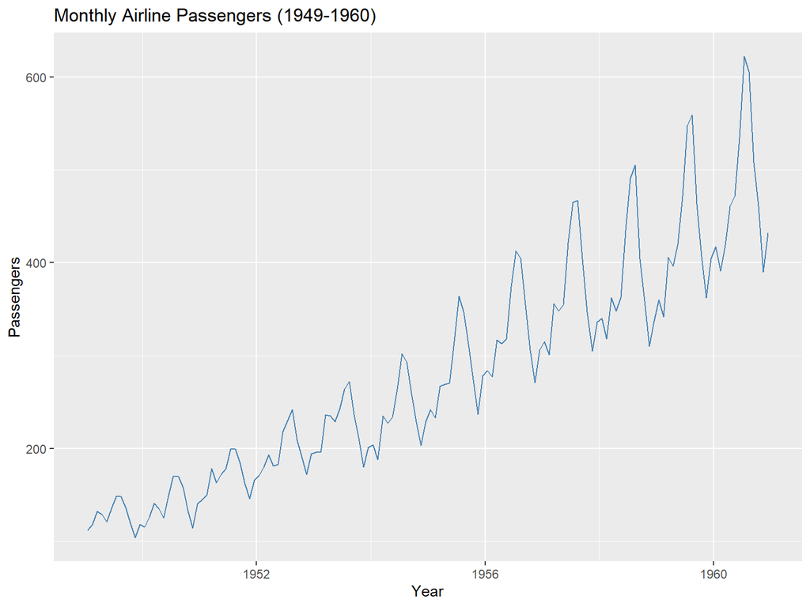

```r
library(ggplot2)
ggplot(airpassengers_df, aes(x = Year + (1:12)/12 - 1/24, y = Passengers)) +
  geom_line(color = "steelblue", line_width = 1) +
  labs(
    title = "Monthly Airline Passengers (1949-1960)",
    x = "Year",
    y = "Passengers"
  )
```

# Seasonal Trends

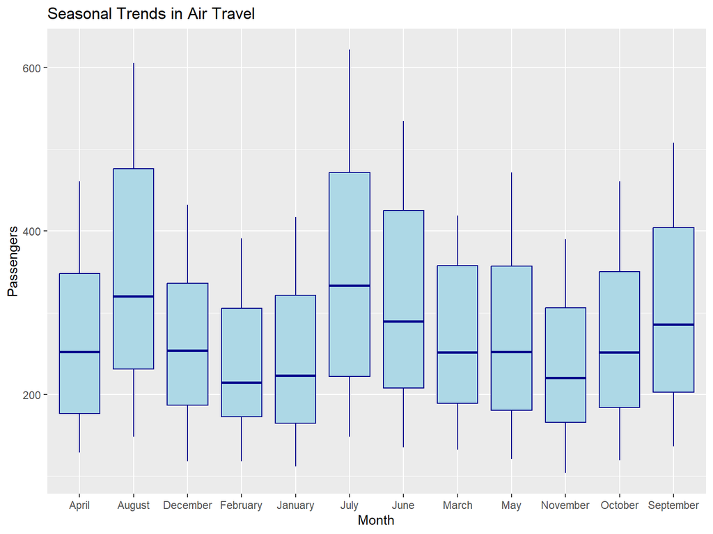

```r
ggplot(airpassengers_df, aes(x = Month, y = Passengers)) +
  geom_boxplot(fill = "lightblue", color = "darkblue") +
  labs(
    title = "Seasonal Trends in Air Travel",
    x = "Month",
    y = "Passengers"
  )
```

# Flight Delays In The new Century (2013)

```r
library(nycflights13)
library(dplyr)
```

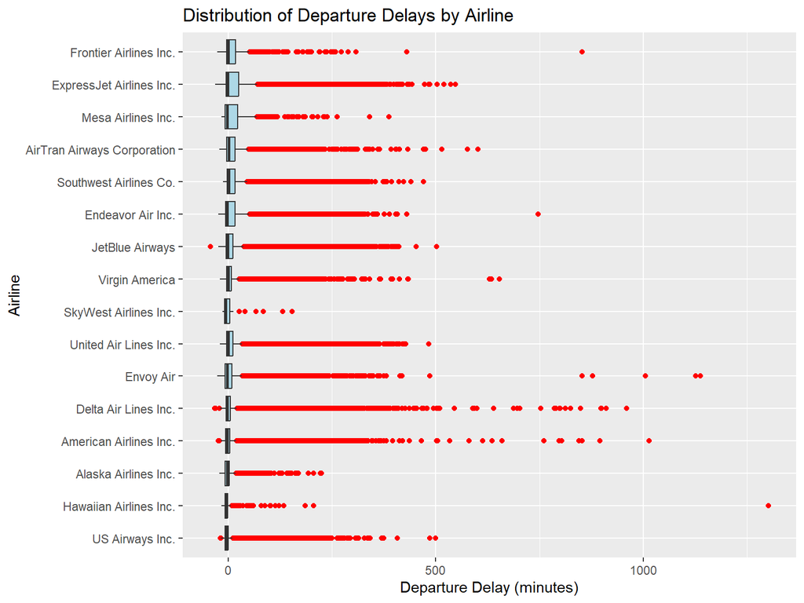

```r
flights_with_airlines <- flights %>%
  filter(!is.na(dep_delay)) %>%
  left_join(airlines, by = "carrier")

ggplot(flights_with_airlines, aes(x = reorder(name, dep_delay), y = dep_delay)) +
  geom_boxplot(outlier.color = "red", fill = "lightblue") +
  coord_flip() +
  labs(
    title = "Distribution of Departure Delays by Airline",
    x = "Airline",
    y = "Departure Delay (minutes)"
  )
```

# What can we deduce from this?

The box plot reveals that some airlines consistently have shorter delays, making them a better choice for timely travel when visiting relatives. To avoid disruptions, consider flying earlier in the day, as delays tend to accumulate later due to cascading scheduling issues. Additionally, avoid airlines with frequent extreme delays (outliers) for smoother travel experiences.

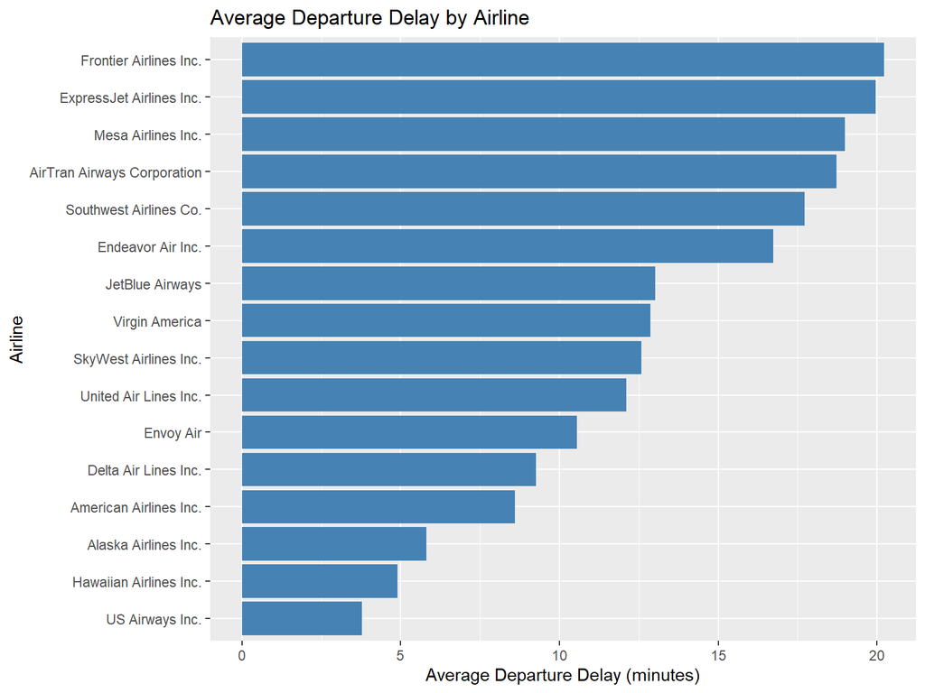

```r
library(ggplot2)

average_delay <- flights_with_airlines %>%
  group_by(name) %>%
  summarise(avg_delay = mean(dep_delay, na.rm = TRUE)) %>%
  arrange(desc(avg_delay))

ggplot(average_delay, aes(x = reorder(name, avg_delay), y = avg_delay)) +
  geom_bar(stat = "identity", fill = "steelblue") +
  coord_flip() +
  labs(
    title = "Average Departure Delay by Airline",
    x = "Airline",
    y = "Average Departure Delay (minutes)"
  )
```

# Summary: Challenges and Observations in Air Travel

Air travel has many issues, such as flight delays, cancellations, overbooking, and problems with baggage. Our study of the AirPassengers data shows a longterm increase in airline passengers, with seasonal highs and lows that match general travel trends. By examining flight delay data from 2013, we found out how delays differ between airlines, identifying which ones have more frequent or severe delays.

The box plots in our analysis show significant differences in departure delays among airlines. Some airlines consistently have delays, while others have better on-time performance. This information can help travelers choose airlines more wisely, possibly improving their travel experience by avoiding carriers with frequent delays or extreme delays.

# Summary: Implications and Limitations

The results of this study have significant effects for both airlines and travelers. Airlines can use this information to enhance their operations, make their schedules more efficient, and cut down on delays. For travelers, knowing about delay patterns can help them make smarter choices, like picking airlines with fewer delays or booking earlier flights to avoid long waits. This knowledge could also lead to better policies for making air travel more efficient and dependable.